# Problem set 10 answers

S352

Fall 2025

## Teaching Evaluations and Gender

### Is there a difference?

```r
evals <- read.csv("https://www.openintro.org/book/statdata/evals.csv")
aggregate(score ~ gender, FUN = mean, data = evals)
```

```
##   gender    score
## 1 female 4.092821
## 2   male 4.234328
```

```r
t.test(score ~ gender, data = evals)
```

```
##
##  Welch Two Sample t-test
##
## data:  score by gender
## t = -2.7507, df = 398.7, p-value = 0.006218
## alternative hypothesis: true difference in means between group female and group male is not equal to 0
## 95 percent confidence interval:
##  -0.24264375 -0.04037194
## sample estimates:
## mean in group female   mean in group male
##             4.092821             4.234328
```

The average evaluation score is 4.09 for female instructors and 4.23 for male instructors, so the male sample average is higher by 0.14 points (on the 1–5 scale.) A two-tailed Welch $t$-test of the hypothesis that both populations have the same mean gives a $P$-value of 0.006, meaning there’s evidence that the population means of these two groups are in fact different.

### Gender and beauty

```r
evalsFemale <- subset(evals, gender == "female")
female.lm <- lm(score ~ bty_avg, data = evalsFemale)
female.lm
```

```
##
## Call:
## lm(formula = score ~ bty_avg, data = evalsFemale)
##
## Coefficients:
## (Intercept)      bty_avg
##     3.95006      0.03064
```

```r
evalsMale <- subset(evals, gender == "male")
male.lm <- lm(score ~ bty_avg, data = evalsMale)
male.lm
```

```
##
## Call:
## lm(formula = score ~ bty_avg, data = evalsMale)
##
## Coefficients:
## (Intercept)      bty_avg
##      3.7666       0.1103
```

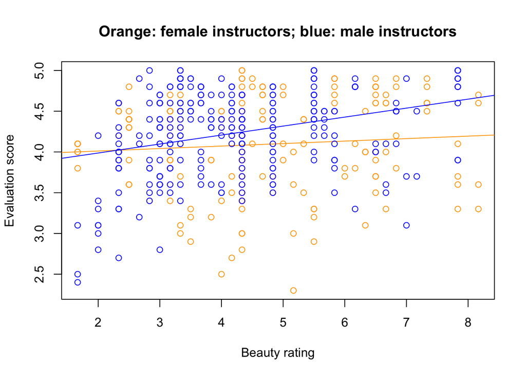

```r
plot(evals$bty_avg, evals$score, type = "n", xlab = "Beauty rating", ylab = "Evaluation score", main = "Orange: female instructors; blue: male instructors")
points(evalsFemale$bty_avg, evalsFemale$score, col = "orange")
abline(female.lm, col = "orange")
points(evalsMale$bty_avg, evalsMale$score, col = "blue")
abline(male.lm, col = "blue")
```

The slope is steeper for male instructors (0.11 to 0.03.) The two regression lines are close together for low beauty ratings, but for higher beauty ratings, male instructors get higher ratings than female instructors on average.

### If you prefer `ggplot()` (optional)

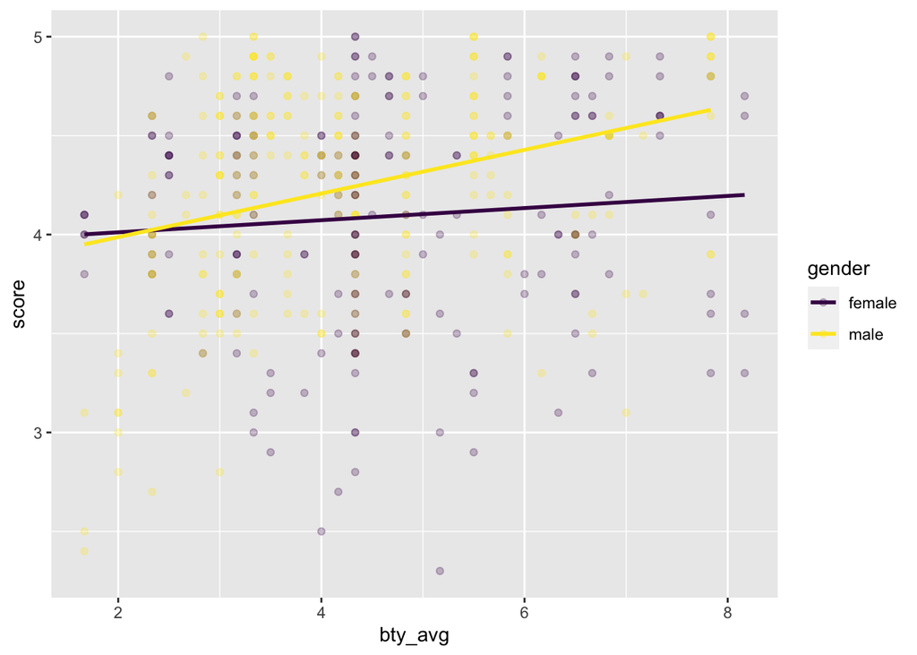

```r
library(ggplot2)
ggplot(evals, aes(x = bty_avg, y = score, color = gender)) +
  geom_point(alpha = 0.25) +
  geom_smooth(method = "lm", se = FALSE) +
  scale_colour_viridis_d()
```

## Rust

### (a) Create variables and data frame

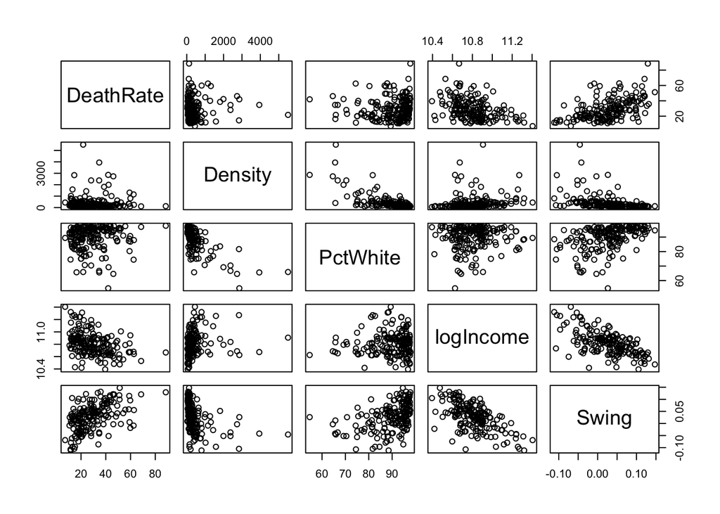

```r
rust <- read.table("rust.txt", header = TRUE)

# variables from the original dataset
PctWhite <- rust$PctWhite
county <- rust$County

# create new variables according to the instructions
DeathRate <- rust$Deaths / rust$Population * 100000
Density <- rust$Population / rust$Area
logIncome <- log(rust$Income)
Swing <- rust$Trump - (1 - rust$Obama)

# create a new data frame
rust2 <- data.frame(DeathRate, Density, PctWhite, logIncome, Swing, county)

# make a pairs plot
pairs(DeathRate ~ Density + PctWhite + logIncome + Swing, data = rust2)
```

### (b) Interaction model

```r
q1model <- lm(DeathRate ~ Swing + Density + Swing:Density, data = rust2)
q1model
```

```
##
## Call:
## lm(formula = DeathRate ~ Swing + Density + Swing:Density, data = rust2)
##
## Coefficients:
##   (Intercept)          Swing        Density  Swing:Density
##     2.257e+01      1.361e+02      7.068e-03      5.347e-02
```

```r
AIC(q1model)
```

```
## [1] 1372.137
```

```r
AIC(lm(DeathRate ~ Swing + Density, data = rust2))
```

```
## [1] 1373.103
```

The AIC of the model with an interaction is 1372.1, which is a bit lower than the AIC of the model without the interaction.

Work out equations for Randolph, Monroe, and Marion Counties:

```r
intercepts <- coef(q1model)[1] + coef(q1model)[3] * c(55, 369, 2375)
slopes <- coef(q1model)[2] + coef(q1model)[4] * c(55, 369, 2375)
intercepts
```

```
## [1] 22.96331 25.18274 39.36167
```

```r
slopes
```

```
## [1] 139.0838 155.8740 263.1392
```

A nicer plot than necessary:

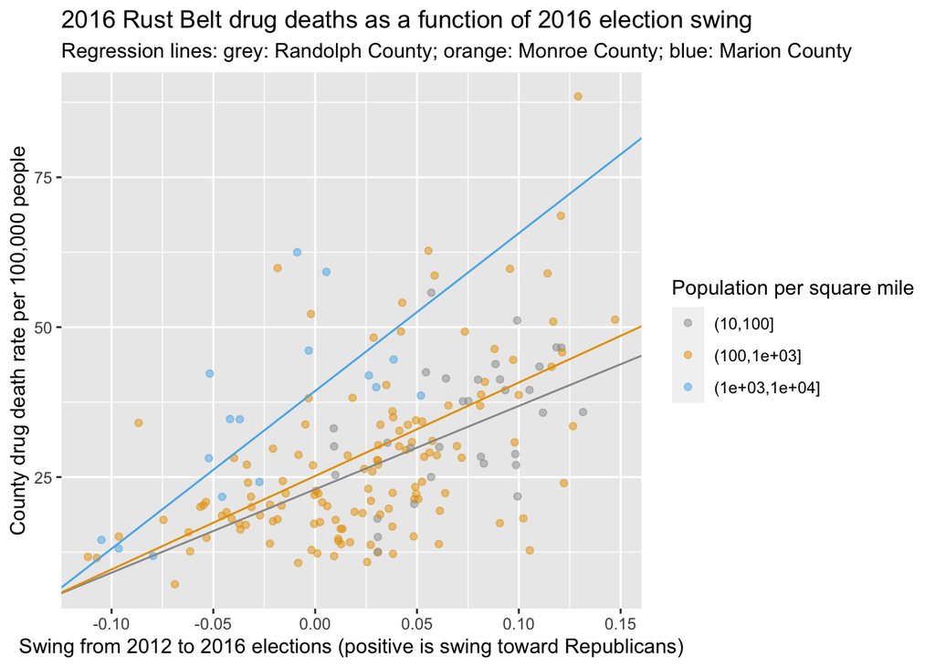

```r
library(ggplot2)
rust2$DensityCat <- cut(rust2$Density, breaks = c(10, 100, 1000, 10000))
ggplot(rust2, aes(x = Swing, y = DeathRate, color = DensityCat)) +
  geom_point(alpha = 0.5) +
  scale_color_manual(values = c("#999999", "#E69F00", "#56B4E9")) +
  geom_abline(intercept = intercepts, slope = slopes, color = c("#999999", "#E69F00", "#56B4E9")) +
  ggtitle("2016 Rust Belt drug deaths as a function of 2016 election swing") +
  xlab("Swing from 2012 to 2016 elections (positive is swing toward Republicans)") +
  ylab("County drug death rate per 100,000 people") +
  labs(color = "Population per square mile", subtitle = c("Regression lines: grey: Randolph County; orange: Monroe County; blue: Marion County"))
```

In general, counties that swung towards Republicans had higher drug death rates, with bigger effects at high densities. However, the right-hand side of the blue line might be an exaggeration: there are no high-density counties that swung much more than 5 percentage points to Republicans, so we don’t know.

### (c) Stepwise selection

Forward selection:

```r
max.model <- lm(DeathRate ~ Density + PctWhite + logIncome + Swing, data = rust2)
step(lm(DeathRate ~ 1, data = rust2), scope = formula(max.model), direction = "forward")
```

```
## Start:  AIC=930.88
## DeathRate ~ 1
##
##             Df Sum of Sq   RSS    AIC
## + Swing      1    8443.6 25216 881.76
## + logIncome  1    5371.5 28288 902.10
## <none>                   33659 930.88
## + PctWhite   1      57.5 33602 932.57
## + Density    1      26.3 33633 932.74
##
## Step:  AIC=881.76
## DeathRate ~ Swing
##
##             Df Sum of Sq   RSS    AIC
## + Density    1   2043.38 23172 868.80
## + PctWhite   1   1343.84 23872 874.06
## + logIncome  1    414.69 24801 880.82
## <none>                   25216 881.76
##
## Step:  AIC=868.8
## DeathRate ~ Swing + Density
##
##             Df Sum of Sq   RSS    AIC
## <none>                   23172 868.80
## + logIncome  1    202.86 22970 869.24
## + PctWhite   1    110.34 23062 869.95
```

```
##
## Call:
## lm(formula = DeathRate ~ Swing + Density, data = rust2)
##
## Coefficients:
## (Intercept)        Swing      Density
##   2.272e+01    1.509e+02    5.408e-03
```

Backward selection:

```r
step(max.model, direction = "backward")
```

```
## Start:  AIC=871.12
## DeathRate ~ Density + PctWhite + logIncome + Swing
##
##             Df Sum of Sq   RSS    AIC
## - PctWhite   1      15.7 22970 869.24
## - logIncome  1     108.2 23062 869.95
## <none>                   22954 871.12
## - Density    1     905.1 23859 875.97
## - Swing      1    4003.3 26957 897.58
##
## Step:  AIC=869.24
## DeathRate ~ Density + logIncome + Swing
##
##             Df Sum of Sq   RSS    AIC
## - logIncome  1     202.9 23172 868.80
## <none>                   22970 869.24
## - Density    1    1831.6 24801 880.82
## - Swing      1    5057.4 28027 902.46
##
## Step:  AIC=868.8
## DeathRate ~ Density + Swing
##
##           Df Sum of Sq   RSS    AIC
## <none>                 23172 868.80
## - Density  1    2043.4 25216 881.76
## - Swing    1   10460.6 33633 932.74
```

```
##
## Call:
## lm(formula = DeathRate ~ Density + Swing, data = rust2)
##
## Coefficients:
## (Intercept)      Density        Swing
##   2.272e+01    5.408e-03    1.509e+02
```

Both ways, starting from empty model:

```r
step(lm(DeathRate ~ 1, data = rust2), scope = formula(max.model), direction = "both", trace = 0)
```

```
##
## Call:
## lm(formula = DeathRate ~ Swing + Density, data = rust2)
##
## Coefficients:
## (Intercept)        Swing      Density
##   2.272e+01    1.509e+02    5.408e-03
```

Both ways, starting from full model:

```r
step(max.model, direction = "both", trace = 0)
```

```
##
## Call:
## lm(formula = DeathRate ~ Density + Swing, data = rust2)
##
## Coefficients:
## (Intercept)      Density        Swing
##   2.272e+01    5.408e-03    1.509e+02
```

All the methods end up converging to the same model:

```r
q2model <- lm(DeathRate ~ Swing + Density, data = rust2)
q2model
```

```
##
## Call:
## lm(formula = DeathRate ~ Swing + Density, data = rust2)
##
## Coefficients:
## (Intercept)        Swing      Density
##   2.272e+01    1.509e+02    5.408e-03
```

$$\textrm{DeathRate} = 22.72 + 150.9 \times \textrm{Swing} + 0.005408
\times \textrm{Density} + \textrm{error}$$

```r
AIC(q2model)
```

```
## [1] 1373.103
```

According to the `AIC()` function, the model has an AIC of 1373.1. (Note that the `step()` function, which treats constants differently, gives an AIC of 868.8. This is a valid answer here, but isn’t comparable to the AIC we calculate in part (b).)